# Step4. STEAM analysis

Please note that some steps have been pre-run in a separate vignette to generate the permutation matrices needed and to only keep genes in the gene lists that are present in the Seurat object after QC filtering.

# 1 Load libraries

Load the necessary libraries.

```r
library(Seurat)
library(SeuratObject)
library(dplyr)
library(MASS)
library(viridis)
library(stringr)
library(ggplot2)
library(readr)
library(steam)
```

# 2 Load data

Load Seurat object.

```r
se <- readRDS("data/human_brain_snRNAseq/se_250_cells_filtered_Metacell_normalized.rds")
se
```

```
## An object of class Seurat
## 42584 features across 715 samples within 2 assays
## Active assay: SCT (21292 features, 3000 variable features)
##  3 layers present: counts, data, scale.data
##  1 other assay present: RNA
```

```r
head(se[[]])
```

```
##                                 orig.ident nCount_RNA nFeature_RNA
## Amygdala excitatory_4  Amygdala excitatory     271833        15035
## Amygdala excitatory_11 Amygdala excitatory     216613        13864
## Amygdala excitatory_13 Amygdala excitatory     217422        15079
## Amygdala excitatory_8  Amygdala excitatory     487621        15607
## Amygdala excitatory_21 Amygdala excitatory     142317        11954
## Amygdala excitatory_22 Amygdala excitatory      61029        10735
##                          supercluster_term nCount_SCT nFeature_SCT
## Amygdala excitatory_4  Amygdala excitatory     112710        12096
## Amygdala excitatory_11 Amygdala excitatory     113143        12030
## Amygdala excitatory_13 Amygdala excitatory     113998        13613
## Amygdala excitatory_8  Amygdala excitatory     112730        11182
## Amygdala excitatory_21 Amygdala excitatory     113930        11954
## Amygdala excitatory_22 Amygdala excitatory     110838        11132
```

Load ranked gene lists (here from Open Targets). Please note that it is essential for downstream analysis that the gene lists are ranked from this point forward to do empirical selection of top genetic genes.

```r
OpenTargets_SCZ_Genetic_ <- as.character(t(read.table(file = "data/OpenTargets/ranked_gene_sets/OT-MONDO_0005090-associated-targets-8_25_2025-v25_06_SCZ_genetic.csv")))
length(OpenTargets_SCZ_Genetic_)
```

```
## [1] 1363
```

# 3 Prepare data for STEAM analysis

Filter out genes not present in the Seurat object.

```r
# Extract gene names from the Seurat object
gene_names <- rownames(se)

# Remove genes not present in the Seurat object from the gene lists
OpenTargets_SCZ_Genetic_ <- unique(OpenTargets_SCZ_Genetic_[OpenTargets_SCZ_Genetic_ %in% gene_names])
length(OpenTargets_SCZ_Genetic_)
```

```
## [1] 1214
```

Generate sliding window gene sets from gene lists. Select your choice of trait abbreviation (disease_abbr) and a gene list descriptive term (ot_gene_set_label). We select a window size of 50 genes, moving by 10 genes for each window.

```r
window_rank_list_SCZ_Genetic <- generate_sliding_windows(OpenTargets_SCZ_Genetic_, window_size = 50, step_size = 10, disease_abbr = "SCZ", ot_gene_set_label = "Genetic")
```

Add gene sets to a list.

```r
all_gene_sets_OpenTargets <- list(OpenTargets_SCZ_Genetic_=OpenTargets_SCZ_Genetic_)
```

Merge all gene sets into one list.

```r
all_gene_sets <- all_gene_sets_OpenTargets
all_gene_sets <- append(all_gene_sets,window_rank_list_SCZ_Genetic)
```

Calculate the average gene expression per gene list and check the percentage of genes present in the Seurat object. It is important that all genes used are present in the Seurat object, otherwise the downstream statistic assumptions are invalid.

```r
score.mat <- matrix(data = NA, nrow = length(all_gene_sets), ncol = 1, dimnames = list(names(all_gene_sets), "% of genes present"))

for (i in 1:length(all_gene_sets)) {
  genes <- unlist(all_gene_sets[i])
  score.mat[i] <- mean(genes %in% rownames(se))
  se <- AddModuleScore(se,list(genes), ctrl = 100, name = list(names(all_gene_sets[i])))
}

score.mat*100
```

```
##                          % of genes present
## OpenTargets_SCZ_Genetic_                100
## SCZ_Genetic_Rank1_                      100
## SCZ_Genetic_Rank2_                      100
## SCZ_Genetic_Rank3_                      100
## SCZ_Genetic_Rank4_                      100
## SCZ_Genetic_Rank5_                      100
## SCZ_Genetic_Rank6_                      100
## SCZ_Genetic_Rank7_                      100
## SCZ_Genetic_Rank8_                      100
## SCZ_Genetic_Rank9_                      100
## SCZ_Genetic_Rank10_                     100
## SCZ_Genetic_Rank11_                     100
## SCZ_Genetic_Rank12_                     100
## SCZ_Genetic_Rank13_                     100
## SCZ_Genetic_Rank14_                     100
## SCZ_Genetic_Rank15_                     100
## SCZ_Genetic_Rank16_                     100
## SCZ_Genetic_Rank17_                     100
## SCZ_Genetic_Rank18_                     100
## SCZ_Genetic_Rank19_                     100
## SCZ_Genetic_Rank20_                     100
## SCZ_Genetic_Rank21_                     100
## SCZ_Genetic_Rank22_                     100
## SCZ_Genetic_Rank23_                     100
## SCZ_Genetic_Rank24_                     100
## SCZ_Genetic_Rank25_                     100
## SCZ_Genetic_Rank26_                     100
## SCZ_Genetic_Rank27_                     100
## SCZ_Genetic_Rank28_                     100
## SCZ_Genetic_Rank29_                     100
## SCZ_Genetic_Rank30_                     100
## SCZ_Genetic_Rank31_                     100
## SCZ_Genetic_Rank32_                     100
## SCZ_Genetic_Rank33_                     100
## SCZ_Genetic_Rank34_                     100
## SCZ_Genetic_Rank35_                     100
## SCZ_Genetic_Rank36_                     100
## SCZ_Genetic_Rank37_                     100
## SCZ_Genetic_Rank38_                     100
```

[output cut: 64 more lines]

```
## SCZ_Genetic_Rank103_                    100
## SCZ_Genetic_Rank104_                    100
## SCZ_Genetic_Rank105_                    100
## SCZ_Genetic_Rank106_                    100
## SCZ_Genetic_Rank107_                    100
## SCZ_Genetic_Rank108_                    100
## SCZ_Genetic_Rank109_                    100
## SCZ_Genetic_Rank110_                    100
## SCZ_Genetic_Rank111_                    100
## SCZ_Genetic_Rank112_                    100
## SCZ_Genetic_Rank113_                    100
## SCZ_Genetic_Rank114_                    100
## SCZ_Genetic_Rank115_                    100
## SCZ_Genetic_Rank116_                    100
## SCZ_Genetic_Rank117_                    100
```

Load permutation matrices for your selected window size and genetic gene list (see separate vignette on how to generate these). OBS! Make sure that you create the Seurat object in the same way (package and filtering) when generating permutation matrices as when you run STEAM.

```r
perm_files <- c(
  "data/human_brain_snRNAseq/permutation_matrices/perm.mat.par_p10000_g50.rds"
)

perm_matrices <- load_permutation_matrices(perm_files)
perm.mat.window.data <- as.data.frame(perm_matrices[[1]])

perm.mat.window.data[1:5,1:5]
```

```
##          Amygdala excitatory   Astrocyte Bergmann glia Cerebellar inhibitory
## Perm_nr1         -0.02221994 -0.02121103   -0.05978827           0.010421139
## Perm_nr2         -0.04722349  0.10191393    0.10423341           0.008504910
## Perm_nr3         -0.03783254 -0.04946540   -0.04627780           0.021161466
## Perm_nr4          0.04210212  0.03261598    0.01009194          -0.005773722
## Perm_nr5          0.02043341 -0.04889645   -0.02980665          -0.035897451
##          CGE interneuron
## Perm_nr1    -0.030625621
## Perm_nr2     0.017654574
## Perm_nr3     0.040846224
## Perm_nr4    -0.007470271
## Perm_nr5    -0.096566175
```

# 4 Empirical selection of top genetic genes

Derive an empirical threshold for top genes of a ranked gene list by comparing the ranked window gene set signal to a null gene set of equal size.

```r
 window_results.g <- window_rank_enrichment_analysis(
   se = se,
   perm.mat.window.data = perm.mat.window.data,
   window_rank_list = window_rank_list_SCZ_Genetic,
   ot_gene_set_label = "Genetic",
   disease_abbr = "SCZ",
   cluster_anno = "supercluster_term",
   imputation = "dynamic"#,
   #log_file = "data/human_brain_snRNAseq/log_files/log_file_pval_mat_genetic_window_SC_SCZ.txt"
 )

head(window_results.g)
```

```
##                                                                   cluster
## SCZ_Genetic_cluster_Amygdala excitatory_Rank1 cluster_Amygdala excitatory
## SCZ_Genetic_cluster_Amygdala excitatory_Rank2 cluster_Amygdala excitatory
## SCZ_Genetic_cluster_Amygdala excitatory_Rank3 cluster_Amygdala excitatory
## SCZ_Genetic_cluster_Amygdala excitatory_Rank4 cluster_Amygdala excitatory
## SCZ_Genetic_cluster_Amygdala excitatory_Rank5 cluster_Amygdala excitatory
## SCZ_Genetic_cluster_Amygdala excitatory_Rank6 cluster_Amygdala excitatory
##                                               window median_score   p_value
## SCZ_Genetic_cluster_Amygdala excitatory_Rank1      1    0.8085572 9.999e-05
## SCZ_Genetic_cluster_Amygdala excitatory_Rank2      2    0.7894836 9.999e-05
## SCZ_Genetic_cluster_Amygdala excitatory_Rank3      3    0.7120172 9.999e-05
## SCZ_Genetic_cluster_Amygdala excitatory_Rank4      4    0.5045196 9.999e-05
## SCZ_Genetic_cluster_Amygdala excitatory_Rank5      5    0.6079282 9.999e-05
## SCZ_Genetic_cluster_Amygdala excitatory_Rank6      6    0.4605965 9.999e-05
##                                                       q05        q95
## SCZ_Genetic_cluster_Amygdala excitatory_Rank1 -0.08157207 0.09025598
## SCZ_Genetic_cluster_Amygdala excitatory_Rank2 -0.08157207 0.09025598
## SCZ_Genetic_cluster_Amygdala excitatory_Rank3 -0.08157207 0.09025598
## SCZ_Genetic_cluster_Amygdala excitatory_Rank4 -0.08157207 0.09025598
## SCZ_Genetic_cluster_Amygdala excitatory_Rank5 -0.08157207 0.09025598
## SCZ_Genetic_cluster_Amygdala excitatory_Rank6 -0.08157207 0.09025598
##                                               is_significant was_imputed
## SCZ_Genetic_cluster_Amygdala excitatory_Rank1           TRUE        TRUE
## SCZ_Genetic_cluster_Amygdala excitatory_Rank2           TRUE        TRUE
## SCZ_Genetic_cluster_Amygdala excitatory_Rank3           TRUE        TRUE
## SCZ_Genetic_cluster_Amygdala excitatory_Rank4           TRUE        TRUE
## SCZ_Genetic_cluster_Amygdala excitatory_Rank5           TRUE        TRUE
## SCZ_Genetic_cluster_Amygdala excitatory_Rank6           TRUE        TRUE
##                                               imputation_type
## SCZ_Genetic_cluster_Amygdala excitatory_Rank1         dynamic
## SCZ_Genetic_cluster_Amygdala excitatory_Rank2         dynamic
## SCZ_Genetic_cluster_Amygdala excitatory_Rank3         dynamic
## SCZ_Genetic_cluster_Amygdala excitatory_Rank4         dynamic
## SCZ_Genetic_cluster_Amygdala excitatory_Rank5         dynamic
## SCZ_Genetic_cluster_Amygdala excitatory_Rank6         dynamic
```

Plot median scores for each window in each cluster. Use these to identify sets of top genes. The lines represent the null distribution where, blue line = median, bright red = 95-quantile, dark red = max value. Here we see that for several clusters the top windows have signal above the max value, and we know the window size is 50 and moves by 10. Thus, we select the top 390 genes in this list to be our top set of genes.

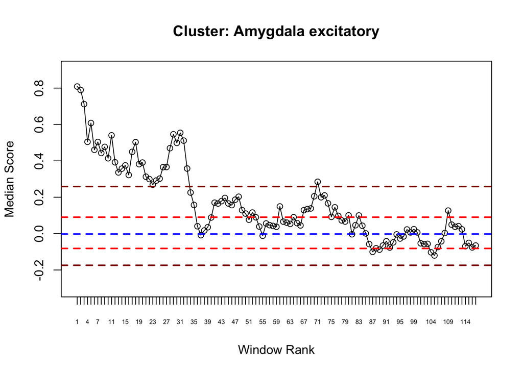

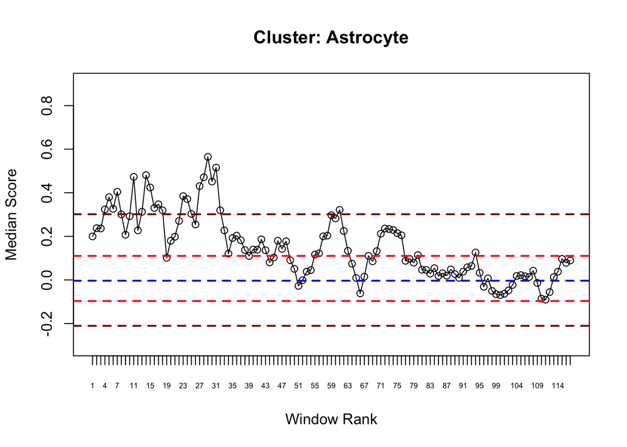

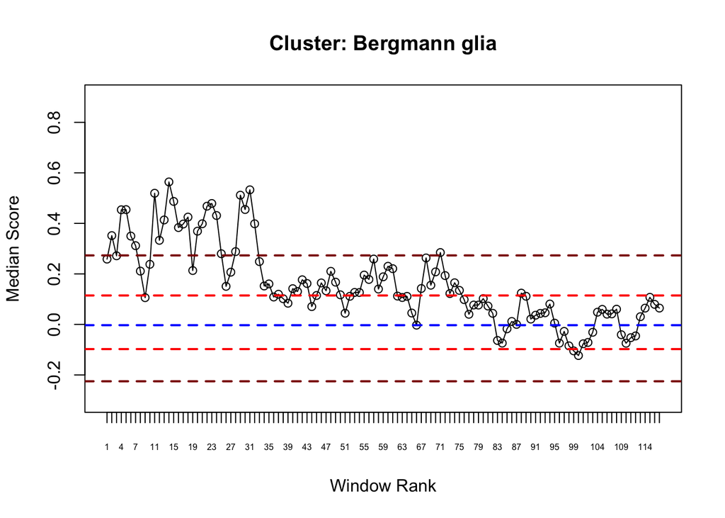

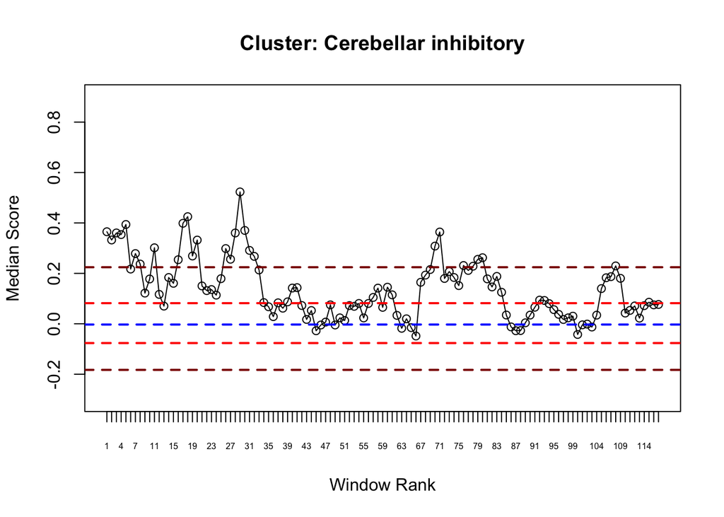

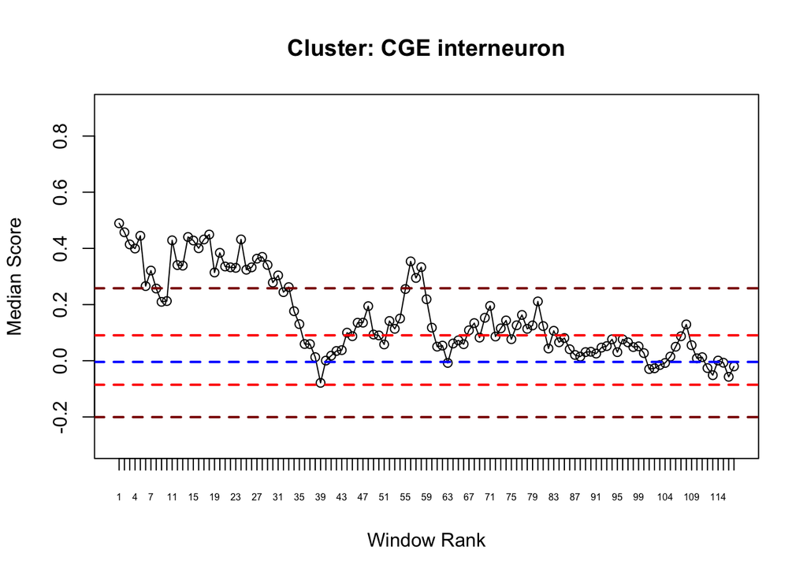

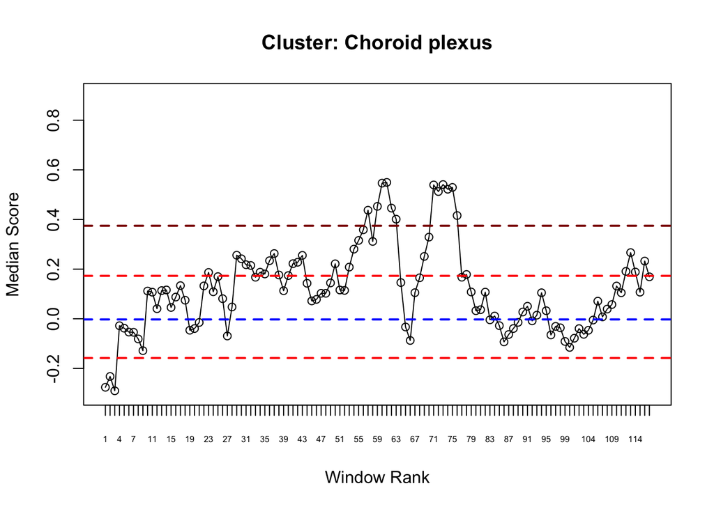

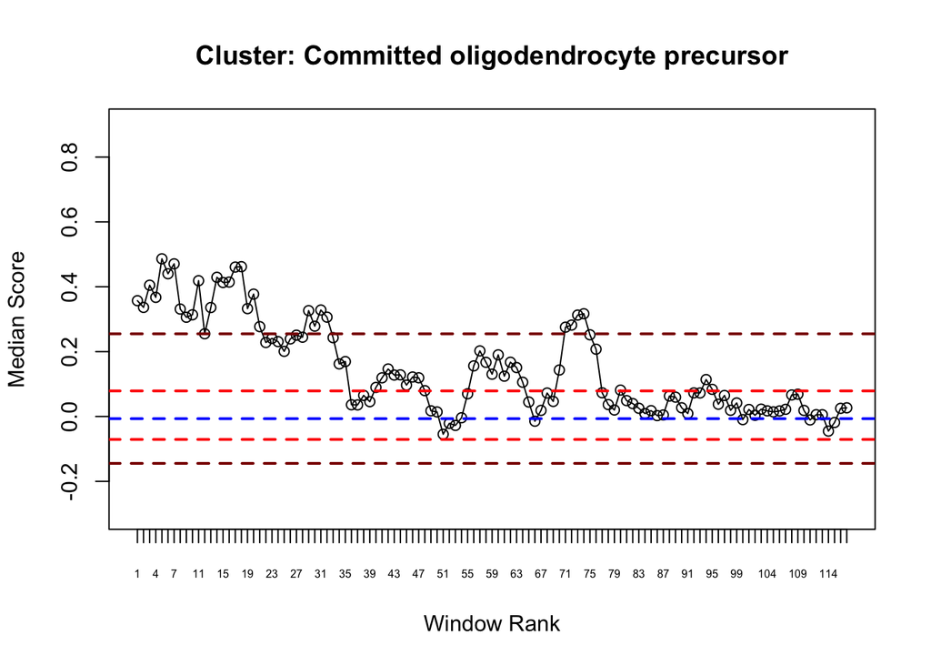

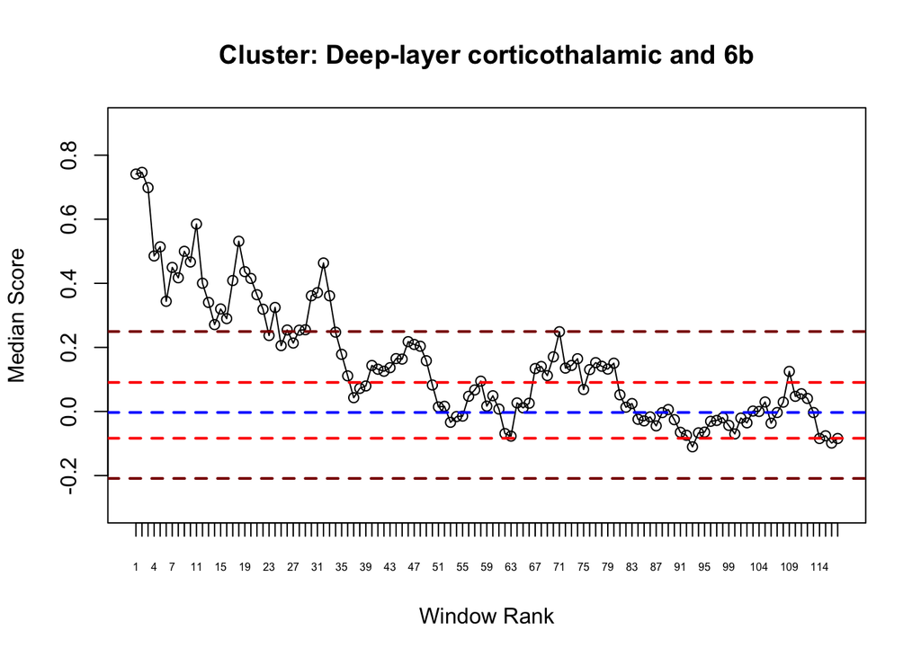

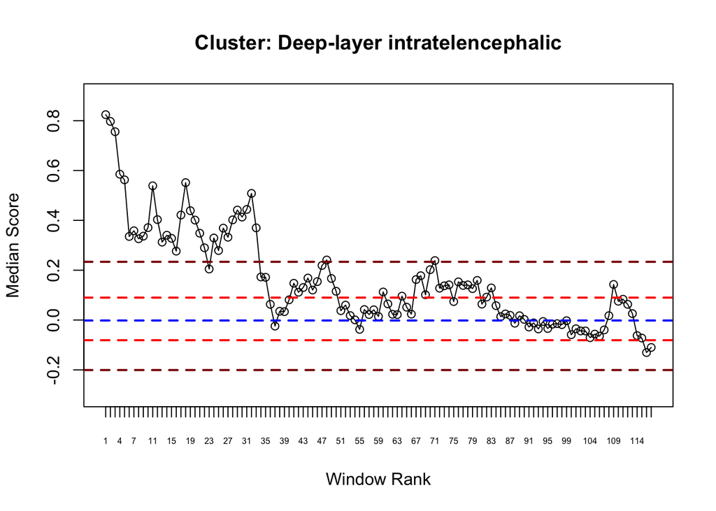

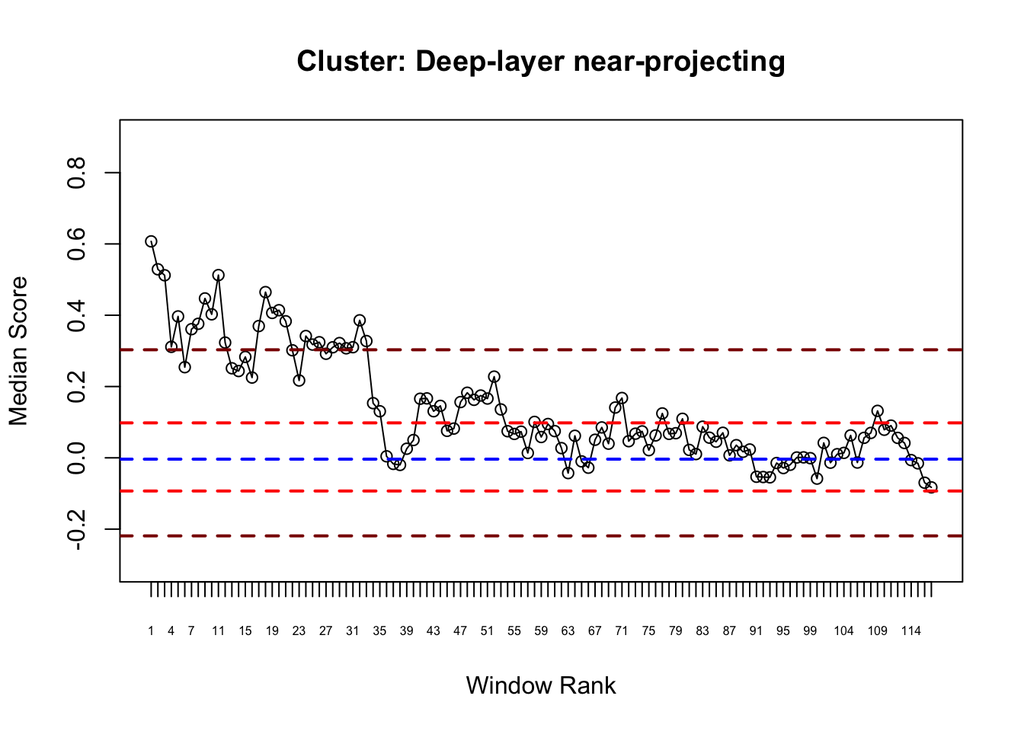

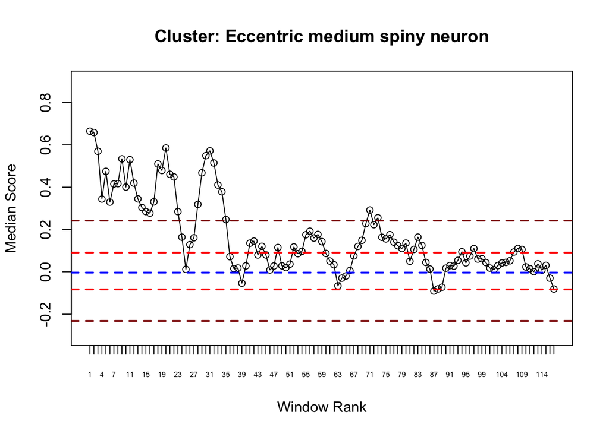

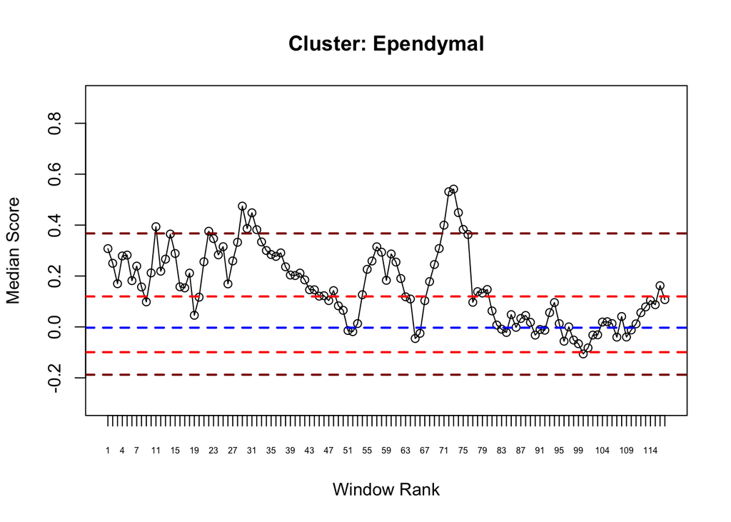

[19 more figures not shown]

```r
 rank_plot_for_clusters(
   window_results = window_results.g,
   perm.mat.window = perm.mat.window.data,
   ylim = c(-0.3, 0.9)
 )
```

# 5 Plot sliding window enrichment

Do multiple correction of p-values based on number of windows.

```r
window_results.g$p_value.adj <- p.adjust(window_results.g$p_value,method = "BH")
```

Add stars for plotting based on p_value.adj.

```r
window_results.g <- window_results.g%>%
  mutate(significance.level = ifelse(p_value.adj < 0.001, "***",
                     ifelse(p_value.adj < 0.01, "**",
                     ifelse(p_value.adj < 0.05, "*",
                     ""))))


window_results.g <- window_results.g%>%
  mutate(significant = ifelse(p_value.adj < 0.05, "TRUE",
                     "FALSE"))


head(window_results.g)
```

```
##                                                                   cluster
## SCZ_Genetic_cluster_Amygdala excitatory_Rank1 cluster_Amygdala excitatory
## SCZ_Genetic_cluster_Amygdala excitatory_Rank2 cluster_Amygdala excitatory
## SCZ_Genetic_cluster_Amygdala excitatory_Rank3 cluster_Amygdala excitatory
## SCZ_Genetic_cluster_Amygdala excitatory_Rank4 cluster_Amygdala excitatory
## SCZ_Genetic_cluster_Amygdala excitatory_Rank5 cluster_Amygdala excitatory
## SCZ_Genetic_cluster_Amygdala excitatory_Rank6 cluster_Amygdala excitatory
##                                               window median_score   p_value
## SCZ_Genetic_cluster_Amygdala excitatory_Rank1      1    0.8085572 9.999e-05
## SCZ_Genetic_cluster_Amygdala excitatory_Rank2      2    0.7894836 9.999e-05
## SCZ_Genetic_cluster_Amygdala excitatory_Rank3      3    0.7120172 9.999e-05
## SCZ_Genetic_cluster_Amygdala excitatory_Rank4      4    0.5045196 9.999e-05
## SCZ_Genetic_cluster_Amygdala excitatory_Rank5      5    0.6079282 9.999e-05
## SCZ_Genetic_cluster_Amygdala excitatory_Rank6      6    0.4605965 9.999e-05
##                                                       q05        q95
## SCZ_Genetic_cluster_Amygdala excitatory_Rank1 -0.08157207 0.09025598
## SCZ_Genetic_cluster_Amygdala excitatory_Rank2 -0.08157207 0.09025598
## SCZ_Genetic_cluster_Amygdala excitatory_Rank3 -0.08157207 0.09025598
## SCZ_Genetic_cluster_Amygdala excitatory_Rank4 -0.08157207 0.09025598
## SCZ_Genetic_cluster_Amygdala excitatory_Rank5 -0.08157207 0.09025598
## SCZ_Genetic_cluster_Amygdala excitatory_Rank6 -0.08157207 0.09025598
##                                               is_significant was_imputed
## SCZ_Genetic_cluster_Amygdala excitatory_Rank1           TRUE        TRUE
## SCZ_Genetic_cluster_Amygdala excitatory_Rank2           TRUE        TRUE
## SCZ_Genetic_cluster_Amygdala excitatory_Rank3           TRUE        TRUE
## SCZ_Genetic_cluster_Amygdala excitatory_Rank4           TRUE        TRUE
## SCZ_Genetic_cluster_Amygdala excitatory_Rank5           TRUE        TRUE
## SCZ_Genetic_cluster_Amygdala excitatory_Rank6           TRUE        TRUE
##                                               imputation_type  p_value.adj
## SCZ_Genetic_cluster_Amygdala excitatory_Rank1         dynamic 0.0004428571
## SCZ_Genetic_cluster_Amygdala excitatory_Rank2         dynamic 0.0004428571
## SCZ_Genetic_cluster_Amygdala excitatory_Rank3         dynamic 0.0004428571
## SCZ_Genetic_cluster_Amygdala excitatory_Rank4         dynamic 0.0004428571
## SCZ_Genetic_cluster_Amygdala excitatory_Rank5         dynamic 0.0004428571
## SCZ_Genetic_cluster_Amygdala excitatory_Rank6         dynamic 0.0004428571
##                                               significance.level significant
## SCZ_Genetic_cluster_Amygdala excitatory_Rank1                ***        TRUE
## SCZ_Genetic_cluster_Amygdala excitatory_Rank2                ***        TRUE
## SCZ_Genetic_cluster_Amygdala excitatory_Rank3                ***        TRUE
## SCZ_Genetic_cluster_Amygdala excitatory_Rank4                ***        TRUE
## SCZ_Genetic_cluster_Amygdala excitatory_Rank5                ***        TRUE
## SCZ_Genetic_cluster_Amygdala excitatory_Rank6                ***        TRUE
```

Update cluster names in the cluster column.

```r
window_results.g$cluster <- gsub("^cluster_", "", window_results.g$cluster)
```

Plot WindowRankEnrichmentAnalysis results.

```r
# Set the order of window based on the original order of rbind
window_results.g$window <- factor(window_results.g$window,
                                     rev(unique(window_results.g$window)))


# Create the plot
p_all <- window_results.g %>%
  ggplot(aes(x = cluster, y = window)) +
  geom_tile(aes(fill = -log10(p_value.adj)), colour = "grey20") +  # Fill with adjusted p-value
  geom_text(data = window_results.g %>% filter(significant == TRUE),
            aes(label = significance.level),
            vjust = 0.75,
            size = 10,
            fontface = "bold") +
  theme(
    legend.key.width = unit(1.5, "cm"),
    legend.key.height = unit(1.5, "cm"),
    axis.text.x = element_text(angle = 90, vjust = 0.5, hjust = 1, size = 40),
    axis.text.y = element_text(size = 15),axis.title.x = element_text(size = 40, face = "bold"),axis.title.y = element_text(size = 40, face = "bold"),plot.title = element_text(size = 50, face = "bold"),legend.title = element_text(size = 40),legend.text = element_text(size = 40)
  ) +
  scale_x_discrete(labels = function(x) str_wrap(x, width = 22)) +
  coord_fixed(ratio = 0.25) +  # May need to adjust or remove if you want free y scaling
  labs(title = "All genetically associated SCZ genes",x = "Cluster", y = "Window rank", fill = "-log10(adj p-value) \n Benjamini & Hochberg") +
  scale_fill_viridis_c(begin = 0.2, option = "viridis") +
  scale_color_manual(values = c("*" = "white", "**" = "white", "***" = "white"),
                     labels = c("***" = "***  p < 0.001", "**" = "**  p < 0.01", "*" = "*  p < 0.05"),
                     guide = guide_legend(override.aes = list(shape = c(21, 21, 23),
                                                              fill = c("white", "white", "white"),
                                                              size = 4)))

p_all
```

[figure not shown]

PDF

```r
pdf(file = "data/human_brain_snRNAseq/STEAM_plots/WindowRankEnrichmentPlot_SCZ_adult.pdf", height = 50, width = 50)

p_all

dev.off()
```

# 6 Fisher’s exact test

Load DEGs data.

```r
DEG_genes <- read_csv2("data/human_brain_snRNAseq/DEG_output/DE_genes.csv")
DEG_genes <- as.data.frame(DEG_genes)
DEG_genes$p_val_adj <- as.numeric(DEG_genes$p_val_adj)
DEG_genes <- subset(DEG_genes, subset = p_val_adj <= 0.05) # using only significant DEG
```

Subset to select the top ranked genes.

```r
OpenTargets_SCZ_Genetic_top <- OpenTargets_SCZ_Genetic_[1:390]
length(OpenTargets_SCZ_Genetic_top)
```

```
## [1] 390
```

Run Fisher’s exact test.

```r
fisher_results <- run_fisher_test_degs(se, DEG_genes = DEG_genes, OT_genes = OpenTargets_SCZ_Genetic_top)
fisher_results
```

```
##                                cluster      p_value odds_ratio  adj_p_value
## 1                  Amygdala excitatory 4.246311e-06   2.401866 1.316356e-04
## 2                            Astrocyte 8.404888e-08   2.609296 2.605515e-06
## 3                        Bergmann glia 8.027235e-11   3.087738 2.488443e-09
## 4                Cerebellar inhibitory 1.222417e-08   3.407412 3.789494e-07
## 5                      CGE interneuron 7.530232e-04   2.354822 2.334372e-02
## 6                       Choroid plexus 2.104751e-02   1.365365 6.524729e-01
## 7  Committed oligodendrocyte precursor 2.070361e-06   3.078051 6.418120e-05
## 8    Deep-layer corticothalamic and 6b 5.340805e-08   2.830981 1.655650e-06
## 9        Deep-layer intratelencephalic 3.259366e-06   2.496654 1.010404e-04
## 10          Deep-layer near-projecting 2.652875e-06   2.273627 8.223912e-05
## 11       Eccentric medium spiny neuron 7.282900e-15   4.338114 2.257699e-13
## 12                           Ependymal 2.376432e-02   1.480026 7.366939e-01
## 13                          Fibroblast 9.658072e-03   1.672300 2.994002e-01
## 14                   Hippocampal CA1-3 7.704617e-08   2.379546 2.388431e-06
```

[output cut: 17 more lines]

Plot results.

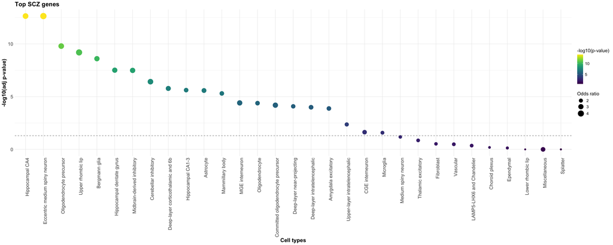

```r
# Ensure clusters are ordered by significance
fisher_results$cluster <- factor(fisher_results$cluster,
                                 levels = fisher_results$cluster[order(fisher_results$adj_p_value)])

# Create the updated plot with viridis scale
p1 <- ggplot(fisher_results, aes(x = cluster, color = -log10(p_value), y = -log10(adj_p_value), size = odds_ratio)) +
  geom_point() +
  geom_hline(yintercept = -log10(0.05), linetype = "dashed", color = "gray50") +
  scale_color_viridis(option = "D", direction = 1, name = "-log10(p-value)") +  # Use Viridis color scale
  scale_size_continuous(range = c(2, 8), name = "Odds ratio") +
  theme_minimal() +
  theme(axis.text.x = element_text(angle = 90, hjust = 1,size = 14),axis.text.y = element_text(size = 14),axis.title.x = element_text(size = 16, face = "bold"),axis.title.y = element_text(size = 16, face = "bold"),plot.title = element_text(size = 18, face = "bold"),legend.title = element_text(size = 14),legend.text = element_text(size = 12)) +
  labs(title = "Top SCZ genes",
       x = "Cell types",
       y = "-log10(adj p-value)") +
  guides(color = guide_colorbar(order = 1), size = guide_legend(order = 2))

p1
```

PDF

```r
pdf(file = "data/human_brain_snRNAseq/STEAM_plots/fishers_exact_test_DEGup_topSTEAM_SCZ_adult.pdf", height = 7, width = 12)

p1

dev.off()
```

Run Fisher’s exact test.

```r
fisher_results <- run_fisher_test_degs(se, DEG_genes = DEG_genes, OT_genes = OpenTargets_SCZ_Genetic_)
fisher_results
```

```
##                                cluster      p_value odds_ratio  adj_p_value
## 1                  Amygdala excitatory 3.287377e-02  1.2896389 1.000000e+00
## 2                            Astrocyte 1.285151e-04  1.5700634 3.983968e-03
## 3                        Bergmann glia 1.334724e-09  2.0012143 4.137644e-08
## 4                Cerebellar inhibitory 3.710112e-11  2.5262867 1.150135e-09
## 5                      CGE interneuron 1.916898e-03  1.6591227 5.942384e-02
## 6                       Choroid plexus 1.199274e-06  1.4982791 3.717750e-05
## 7  Committed oligodendrocyte precursor 1.595563e-04  1.8302587 4.946246e-03
## 8    Deep-layer corticothalamic and 6b 1.950357e-04  1.6123940 6.046106e-03
## 9        Deep-layer intratelencephalic 2.209937e-03  1.4810192 6.850804e-02
## 10          Deep-layer near-projecting 7.906718e-03  1.3421395 2.451083e-01
## 11       Eccentric medium spiny neuron 1.659239e-10  2.3314197 5.143640e-09
## 12                           Ependymal 2.754256e-03  1.3777607 8.538194e-02
## 13                          Fibroblast 1.225732e-03  1.4862038 3.799768e-02
## 14                   Hippocampal CA1-3 3.457940e-03  1.3533426 1.071961e-01
```

[output cut: 17 more lines]

Plot results.

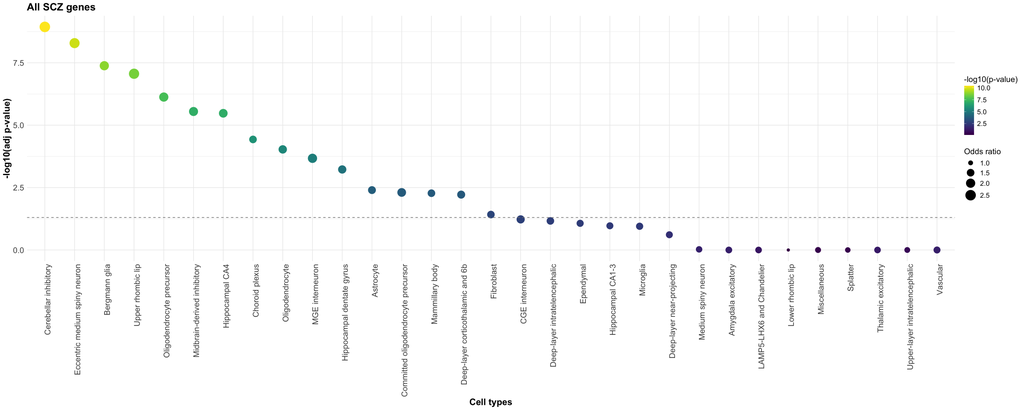

```r
# Ensure clusters are ordered by significance
fisher_results$cluster <- factor(fisher_results$cluster,
                                 levels = fisher_results$cluster[order(fisher_results$adj_p_value)])

# Create the updated plot with viridis scale
p2 <- ggplot(fisher_results, aes(x = cluster, color = -log10(p_value), y = -log10(adj_p_value), size = odds_ratio)) +
  geom_point() +
  geom_hline(yintercept = -log10(0.05), linetype = "dashed", color = "gray50") +
  scale_color_viridis(option = "D", direction = 1, name = "-log10(p-value)") +  # Use Viridis color scale
  scale_size_continuous(range = c(2, 8), name = "Odds ratio") +
  theme_minimal() +
  theme(axis.text.x = element_text(angle = 90, hjust = 1,size = 14),axis.text.y = element_text(size = 14),axis.title.x = element_text(size = 16, face = "bold"),axis.title.y = element_text(size = 16, face = "bold"),plot.title = element_text(size = 18, face = "bold"),legend.title = element_text(size = 14),legend.text = element_text(size = 12)) +
  labs(title = "All SCZ genes",
       x = "Cell types",
       y = "-log10(adj p-value)") +
  guides(color = guide_colorbar(order = 1), size = guide_legend(order = 2))

p2
```

PDF

```r
pdf(file = "data/human_brain_snRNAseq/STEAM_plots/fishers_exact_test_DEGup_all_SCZ_adult.pdf", height = 7, width = 12)

p2

dev.off()
```